# Aside

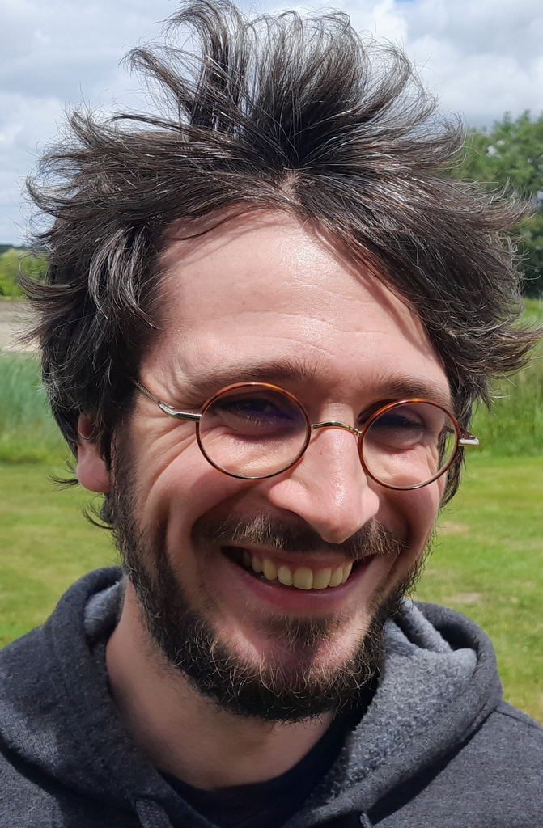

## Contact

- Lyon, France
- +33 667741585
- louismaniere@orange.fr
- github.com/LouisManiere
- [linkedin.com/louis-manière](https://www.linkedin.com/in/louis-mani%C3%A8re-03760750/)

## Data science

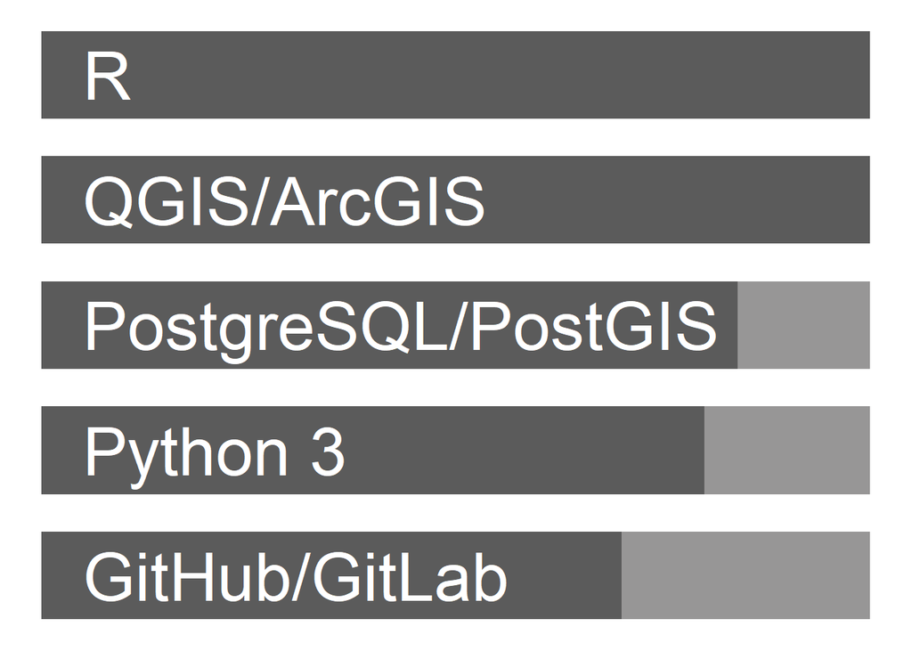

## Instrumentation

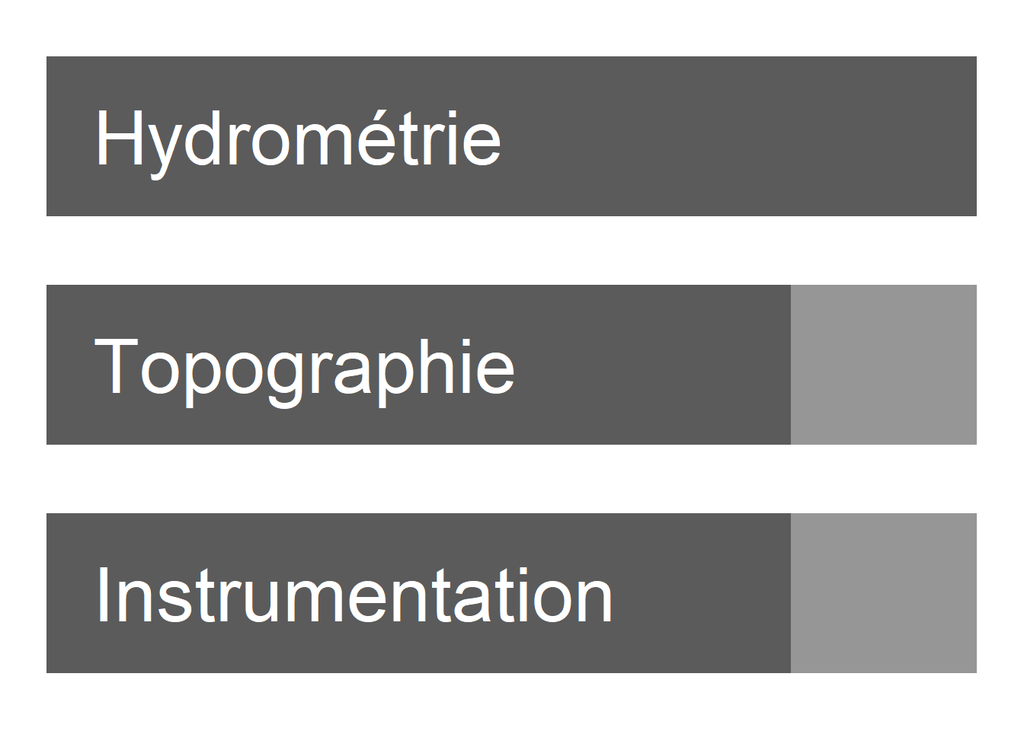

## Web

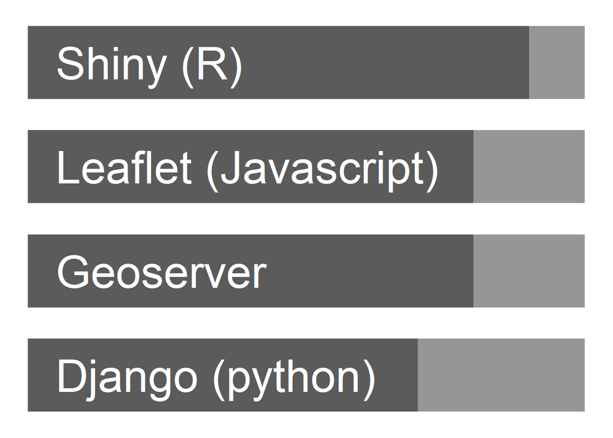

## Savoir être

– A l’écoute des besoins et force de proposition  
– Aisance relationnelle en équipe et à l’oral  
– Organisé et rigoureux

## Disclaimer

Réalisé avec le package R [**pagedown**](https://github.com/rstudio/pagedown).

# Main

## Louis Manière

### Ingénieur en gestion de données et hydrologie

10 ans d’expérience dans l’acquisition, la gestion et le traitement des données avec une spécialisation en hydrologie et environnement.  
Anglais courant

## Expériences professionnelles

### Ingénieur en base de données et instrumentation

Université de Tours - Laboratoire Géohydrosystèmes Continentaux (GeHCO)

Tours

Mars 2024 - Aujourd’hui

- Gestion, traitement et valorisation des données de recherche (contaminants, surplus azotés, érosion des sols, érosion de berges)
- Instrumentation de bassins versants

### Ingénieur en conception d’application interactive en géomorphologie fluviale

CNRS - Laboratoire Environnement, Ville, Société (EVS UMR5600)

Lyon

Janv. 2023 - Févr. 2024

- Rédaction du cahier des charges des besoins et réalisation d’une application cartographique web d’analyse de l’hydromorphologie des cours d’eau français (OFB)

### Géomaticien - auto-entrepreneur

Juillet 2022 - Aujourd’hui

- Mise à jour des programmes de migration de la base de données géographique du projet archéologique européen Desert Networks (Python)
- Création de 15 cartes sur l’analyse d’itinéraires antiques du désert oriental égyptien

### Géomaticien - data ingénieur

METIS - bureau d’études en géomatique et télécommunication

Lyon

Nov. 2021 - Juin 2022

- Développement d’une application web cartographique des guichets d’autorisation d’urbanisme (Django, Leaflet)
- Refonte de la base de données PostgreSQL de production cartographique d’avant projet fibre optique
- Développement de plugins QGIS et d’outils de traitement de données (Python, R, pyqgis 3)

### Ingénieur d’études SIG

CNRS - Histoire et Sources des Mondes Antiques (HiSoMA UMR5189)

Lyon

Févr. 2019 - Août 2021

Responsable des données géographique du projet ERC Desert Networks - [website](https://desertnetworks.huma-num.fr/sites)

- Préparation et vérification de données (géoréférencement, tables attributaires, topologie), analyse de données de réseaux de transport antique
- Administrateur de la base de données PostgreSQL (projet et site internet) et du Geoserver
- Rédaction de datapaper (avec métadonnées ISO 19139) et publication de cartes thématiques
- Production d’outils d’analyse (ArcGIS, QGIS, Python 3, R) et rédaction d’articles scientifiques, blog et documentations

### Ingénieur d’études en hydrologie et environnement

Université de Tours - Laboratoire Géohydrosystèmes Continentaux (GeHCO)

Tours

Janv. 2015 - Janv. 2018

Responsable technique de l’Observatoire du bassin versant Louroux sur l’érosion des sols agricoles (site Zone Atelier Loire)

- Développement de l’instrumentation du suivi hydro-sédimentaire et météorologiques
- Mise en place des chaînes de traitement et suivi qualité des données de l’Observatoire
- Traitement et analyses des données (R, ArcGIS, QGIS) et rédaction des livrables techniques

### Ingénieur d’études en hydromorphologie

INRAE (anc. IRSTEA), équipe Hydroécologie fluviale (HEF)

Antony

Oct. 2013 - oct. 2014

Mesures de terrain sur la morphologie et le transport sédimentaire de 9 plans d’eau arrasés, modélisation spatiale et temporelle de leurs évolutions pour l’aide à la décision de renaturation de cours d’eau (OFB)

## Enseignement

### Statistiques et data mining

Master 1 Hydrosystèmes et Bassins Versants, Université de Tours

Tours

2024

### Métrologie et analyse de données de l’Observatoire du Louroux (terrain et laboratoire)

Master 1 Hydrosystèmes et Bassins Versants, Université de Tours

Tours

2016 - 2018

## Formation continue

### Conception d’interface Shiny (developpeur niveau 3)

ThinkR (formation certifiante), 5 jours

2023

### SIGR, Sciences de l’Information Géographique Reproductibles

Ecole d’été CNRS, 5 jours

2021

### Analyse de données multidimensionelles

CNRS, 2 jours

2020

### Base de données PostgreSQL/PostGIS

Makina Corpus (formation certifiante), 3 jours

2020

### Python pour l’analyse géospatiale

Makina Corpus (formation certifiante), 3 jours

2019

## Formation académique

### Master 2 Sciences de l’eau (anc. Cogeval’eau)

Université Lumière Lyon 2

Lyon

2013

### Master 1 Géographie

Université Paris 1 Panthéon-Sorbonne

Paris

2012

## Bénévolat

### Hydraulique Sans Frontières : Maîtrise d’oeuvre eau et assainissement

Burkina Faso

2019 - Aujourd’hui

### CartONG : OSM et projets cartographiques

2020 - 2021